# Twitter Following vs In-Game Performance of NBA Players

## Introduction

Perhaps more so than in any other American professional sports leage, NBA (National Basketball Association) players are very active off the court, often becoming notable celebrities, social figures, and - in many cases - [brand ambasadors](https://www.forbes.com/sites/kurtbadenhausen/2018/02/17/the-2018-nba-all-stars-players-who-earn-the-most-from-endorsements/#3b8acc511755).

But athletes' presence in popular culture varies wildly from one player to the next. In this tutorial, we attempt to use players' in-game statistics to predict the size of their Twitter following. In addition to just being a potentially interesting correlation to uncover, this model could be used to identify which players have the potential to accrue a larger social impact than the currently have, and thus who could provide a better "bang for your buck" as an endorser.

Now let's dive into the code! We'll start with the imports we need to make the rest of the code work.

```python
# for data collection
!pip install tweepy
from bs4 import BeautifulSoup as bs
import tweepy
import requests
import pandas
import numpy as np
import re
import pickle
# for exploratory data analysis
import matplotlib.pyplot as plt
import seaborn
# for machine learning
from sklearn.linear_model import LinearRegression
from sklearn import linear_model
from sklearn import preprocessing
# for feature selection
from sklearn import feature_selection
from sklearn.ensemble import ExtraTreesClassifier
# for model testing
from sklearn.model_selection import cross_val_score
from sklearn.model_selection import ShuffleSplit
```

```
You are using pip version 9.0.3, however version 18.1 is available.
```

## Data Collection

As is the first step in any good data science project, we need to collect all the data that we will later be performing analysis on. We are going to need gameplay statistics from NBA players (from basketball-reference.com) and also statistics on their Twitter following.

We will start with the gameplay statistics, and to do that we must first compile a list of all the players we are going to investigate. Since Twitter is a relatively new platform compared to the NBA, we will only get data on players who were active during the 2017-18 season, so we do not have to account for the differences caused by being inactive or playing in a previous era. Thus we will get our data from Basketball-Reference's [2018 table](https://www.basketball-reference.com/leagues/NBA_2018_totals.html).

Basketball-Reference does not have a public API, so to get the data, we will have to scrape their site. Parsing HTML manually can be tough, so we instead use an existing library called [Beautiful Soup](https://www.crummy.com/software/BeautifulSoup/). Experienced data scientists will likely already be familiar with this library, but if you're a newbie it's a great starting point as it allows you to very easily ingest data you find online. This [guide](https://www.dataquest.io/blog/web-scraping-tutorial-python/) from Dataquest provides more in-depth information than will be in our tutorial.

By manually inspecting the table element we want to ingest, we find that each row is a `td` element with its `data-stat` attribute set to `player`, so we will use Beautiful Soup to parse the page and find all such elements. We will then use a regex to find the the reference to each player's stats page on Basketball Reference.

Those results will be loaded into a [Pandas](https://pandas.pydata.org/) data frame. Pandas is an open source library providing high-performance, easy-to-use data structures and data analysis tools in Python. It allows us to quickly and easily store, aggregate, and query the data that we have collected. If you are interested in learning more about Pandas and its capabilities beyond those used in this tutorial, check out the [tutorials](https://pandas.pydata.org/pandas-docs/stable/tutorials.html) they have posted on their website.

```python
player_list_text = requests.get('https://www.basketball-reference.com/leagues/NBA_2018_totals.html').text
player_list_soup = bs(player_list_text, 'html.parser')

player_list_html = player_list_soup.find_all('td',attrs={"data-stat": "player"})
player_list_re = re.compile('(/players/\w/.*\.html)')
player_links = [{"name": x.text, "ref": player_list_re.search(x.a['href']).group(1)} for x in player_list_html]
player_links_df = pandas.DataFrame(player_links).drop_duplicates()
player_links_df.head()
```

|  | name | ref |
| --- | --- | --- |
| 0 | Alex Abrines | /players/a/abrinal01.html |
| 1 | Quincy Acy | /players/a/acyqu01.html |
| 2 | Steven Adams | /players/a/adamsst01.html |
| 3 | Bam Adebayo | /players/a/adebaba01.html |
| 4 | Arron Afflalo | /players/a/afflaar01.html |

Following a similar procedure, we will find all the rows on Basketball Reference's page of players' Twitter handles and load them into another data frame.

```python
handle_list_text = requests.get('https://www.basketball-reference.com/friv/twitter.html').text
handle_list_soup = bs(handle_list_text, 'html.parser')

handle_list_html = handle_list_soup.find('table',attrs={"id": "twitter"}).find('tbody').find_all('tr')
handle_list_re = re.compile('https://twitter.com/(.*)')
player_handles = [{"ref": player_list_re.search(x.find_all('a')[0]['href']).group(1), "handle": handle_list_re.search(x.find_all('a')[1]['href']).group(1)} for x in handle_list_html]
player_handles_df = pandas.DataFrame(player_handles)
player_handles_df.head()
```

|  | handle | ref |
| --- | --- | --- |
| 0 | kaj33 | /players/a/abdulka01.html |
| 1 | alexabrines | /players/a/abrinal01.html |
| 2 | QuincyAcy | /players/a/acyqu01.html |
| 3 | 10jadams | /players/a/adamsja01.html |
| 4 | jordanadams1231 | /players/a/adamsjo01.html |

To join these two sets of data, we will perform a merge. We know that both of the tables we just created included the internal reference to the player's page on Basketball Reference, so we can match up records in the two tables using that field. Because we only want to investigate active players who use Twitter, we will use an inner join, meaning we only keep records that were contained in both of the original tables. To learn more about inner and other types of joins, check out this [article](https://www.geeksforgeeks.org/sql-join-set-1-inner-left-right-and-full-joins/).

```python
player_data_df = pandas.merge(player_links_df, player_handles_df, how='inner', on='ref')
player_data_df.head()
```

|  | name | ref | handle |
| --- | --- | --- | --- |
| 0 | Alex Abrines | /players/a/abrinal01.html | alexabrines |
| 1 | Quincy Acy | /players/a/acyqu01.html | QuincyAcy |
| 2 | Steven Adams | /players/a/adamsst01.html | RealStevenAdams |
| 3 | Bam Adebayo | /players/a/adebaba01.html | Bam1of1 |
| 4 | Cole Aldrich | /players/a/aldrico01.html | colea45 |

Now that we have all the players' internal reference links, we will need to be able to turn one of these links into a set of statistics about the player. In particular, we want the career stats Basketball Reference provides (games, games started, various shooting percentages, and various per-game statistics like points, shots, blocks, etc.) The page also contains the player's salary, which seems like it may help predict popularity, so we will include that in the record as well. Finally, we put the provided reference to the data so we can link it up with the rest of the record later.

```python
def get_player_stats(ref) :
    player_stats_text = requests.get('https://www.basketball-reference.com' + ref).text.replace('<!--', '').replace('-->', '')
    player_stats_soup = bs(player_stats_text, 'html.parser')

    player_stats_html = player_stats_soup.find('table',attrs={"id":"per_game"}).find('tfoot').find('tr')
    player_stats = {x['data-stat']: x.text for x in player_stats_html.find_all('td') if len(x.text) > 0}
    player_stats['salary'] = player_stats_soup.find_all('td', attrs={"data-stat": "salary"})[-2]['csk']
    player_stats['ref'] = ref
    return player_stats
```

The page also has some information they call 'Bling,' which are basically just awards that the player has receive during their career. These awards include All-Star appearences, NBA Championship wins, and Most Valuable Player wins. These are events that bring a great deal of media attention to a player, so we believe they map impact social media following. As before, we use Beautiful Soup to parse the page and find the 'Bling' elements, then use regular expressions to extract the number of each of these awards they received.

```python
all_star_re = re.compile('(\d+)(x?) All Star')
champ_re = re.compile('(\d+)(x?) NBA Champ')
mvp_re = re.compile('(\d+)(x?) MVP')

def get_player_bling(ref) :
    player_stats_text = requests.get('https://www.basketball-reference.com' + ref).text.replace('<!--', '').replace('-->', '')
    player_stats_soup = bs(player_stats_text, 'html.parser')
    bling_html = player_stats_soup.find(attrs={"id": "bling"})
    if not bling_html:
        return {'ref': ref, 'all_star': 0, 'champ': 0, 'mvp': 0}
    bling_text = bling_html.text
    all_star_match = all_star_re.search(bling_text)
    champ_match = champ_re.search(bling_text)
    mvp_match = mvp_re.search(bling_text)

    player_bling = {'ref': ref}
    player_bling['all_star'] = 0 if not all_star_match else 1 if all_star_match.group(2) == '' else int(all_star_match.group(1))
    player_bling['champ'] = 0 if not champ_match else 1 if champ_match.group(2) == '' else int(champ_match.group(1))
    player_bling['mvp'] = 0 if not mvp_match else 1 if mvp_match.group(2) == '' else int(mvp_match.group(1))
    return player_bling
```

Finally, we will need to get data related to each of the player's Twitter handles. Given a handle, we will get the number of followers and number of statuses (tweets) associated with that account. We have to deal with a little bit of dirty data at this step, because Basketball Reference's data is not perfect. The two main issues with the data set are that some handles are out of date (player changed handle since being added to table) and others simply have typos.

[figure not shown]

In the case of a typo or an account which no longer exists, we simply return an empty record. The problem is more difficult when we are pointed to an existing Twitter account, but one that does not actually belong to the player. We will get into how we solve this later in the tutorial.

```python
def get_handle_followers(handle, api) :
    try :
        user = api.get_user(handle)
        return {'handle': handle, 'followers_count': user.followers_count, 'statuses_count': user.statuses_count}
    except :
        return {}
```

And now for the moment of truth, we're actually going to get the data! For each of our players, we will get the stats associated with them and store them in a data frame. If you run this code yourself, expect it to take a while (at least 10 minutes) as we have to make a request to Basketball Reference for every single player and their site loads a bit slowly.

```python
player_stats = [get_player_stats(x[1]['ref']) for x in player_data_df.iterrows()]
player_stats_df = pandas.DataFrame(player_stats)
```

Now we will do the same thing but instead of collecting stats, we will get our 'Bling' data. This will take a while too.

```python
player_bling = [get_player_bling(x[1]['ref']) for x in player_data_df.iterrows()]
player_bling_df = pandas.DataFrame(player_bling)
```

Now we will get all the data from Twitter. This requires us to use [Tweepy](http://www.tweepy.org/), a Python library for accessing the Twitter API. And to use this API, we will need an account with developer credentials.

To avoid letting developers use their API to produce spam or manipulate conversations, Twitter now requires that users submit an application to obtain developer credentials. Read more about the reasons behind this decision [here](https://blog.twitter.com/developer/en_us/topics/tools/2018/new-developer-requirements-to-protect-our-platform.html). If you do not already have a developer account, apply [here](https://developer.twitter.com/en/apply-for-access.html).

In the cell below, you will need to enter the authentication tokens from your account. I have revoked tokens below (for obvious reasons) so they will no longer work, but you can use your found here.

[figure not shown]

```python
auth = tweepy.OAuthHandler(<Consumer API key>, <Consumer API secret key>)
auth.set_access_token(<Access token>, <Access token secret>)
api = tweepy.API(auth)

handle_followers = [get_handle_followers(x[1]['handle'], api) for x in player_data_df.iterrows()]
handle_followers_df = pandas.DataFrame(handle_followers)
```

As we mentioned before, some of our handles point to existing accounts but still do not actually belong to the player we think they do. In an attempt to filter these out, we will only keep accounts with at least 50 posts. This may cut out some accounts which really do belong to players, but since the owners of these accounts clearly are not actually active on Twitter, we feel justified in discarding them due to inactivity just as we did players who do not have a Twitter account at all.

```python
handle_followers_df = handle_followers_df[handle_followers_df['statuses_count'] > 50]
```

Now that we have our 4 data sets (player names, stats, bling, and twitter), we can use the same merge command as before to combine these into one data frame. We once again perform an inner merge on the `handle_followers_df` data frame since we want to discard players for whom we could not find an active Twitter account.

```python
player_data_df = pandas.merge(player_data_df, player_stats_df, how='left', on='ref')
player_data_df = pandas.merge(player_data_df, player_bling_df, how='left', on='ref')
player_data_df = pandas.merge(player_data_df, handle_followers_df, how='inner', on='handle')
```

Unfortunately, when we allowed Beautiful Soup to automatically ingest the stats data, it made the data type of all of our columns `object`. We wanted most of them to be numeric, but luckily Pandas has a nice function for this, so we convert all of our numeric columns to numeric dtypes. To learn more about Pandas dtypes, check out [this page](http://pbpython.com/pandas_dtypes.html).

```python
str_cols = ['name', 'ref', 'handle', 'lg_id']
numeric_cols = [x for x in player_data_df if not x in str_cols]
for c in numeric_cols :
    player_data_df[c] = pandas.to_numeric(player_data_df[c])
player_data_df.head()
```

|  | name | ref | handle | ast_per_g | blk_per_g | drb_per_g | efg_pct | fg2_pct | fg2_per_g | fg2a_per_g | ... | pts_per_g | salary | stl_per_g | tov_per_g | trb_per_g | all_star | champ | mvp | followers_count | statuses_count |
| --- | --- | --- | --- | --- | --- | --- | --- | --- | --- | --- | --- | --- | --- | --- | --- | --- | --- | --- | --- | --- | --- |
| 0 | Alex Abrines | /players/a/abrinal01.html | alexabrines | 0.5 | 0.1 | 1.1 | 0.523 | 0.434 | 0.5 | 1.1 | ... | 5.3 | 5725000 | 0.5 | 0.4 | 1.4 | 0 | 0 | 0 | 48165.0 | 1658.0 |
| 1 | Quincy Acy | /players/a/acyqu01.html | QuincyAcy | 0.6 | 0.4 | 2.6 | 0.517 | 0.505 | 1.2 | 2.4 | ... | 5.0 | 1709538 | 0.4 | 0.7 | 3.5 | 0 | 0 | 0 | 35969.0 | 15786.0 |
| 2 | Steven Adams | /players/a/adamsst01.html | RealStevenAdams | 0.9 | 1.0 | 3.9 | 0.587 | 0.588 | 3.8 | 6.4 | ... | 9.2 | 22471910 | 0.8 | 1.4 | 7.1 | 0 | 0 | 0 | 197311.0 | 1454.0 |
| 3 | Bam Adebayo | /players/a/adebaba01.html | Bam1of1 | 1.5 | 0.7 | 4.1 | 0.522 | 0.533 | 2.7 | 5.0 | ... | 7.3 | 2490360 | 0.5 | 1.0 | 6.0 | 0 | 0 | 0 | 68471.0 | 14055.0 |
| 4 | Cole Aldrich | /players/a/aldrico01.html | colea45 | 0.5 | 0.7 | 2.4 | 0.527 | 0.527 | 1.3 | 2.4 | ... | 3.1 | 7300000 | 0.4 | 0.6 | 3.3 | 0 | 0 | 0 | 54059.0 | 3000.0 |

5 rows × 35 columns

Now that we have made the necessary columns numeric, we will notice that some of our data is missing. In particular, we see that all of the percentage statistics contain some NaN's. This is not too surprising as players with no 3 point shot attempts, for example, will have a NaN 3 point shooting percentage.

```python
player_data_df.isnull().any()
```

```
name               False
ref                False
handle             False
ast_per_g          False
blk_per_g          False
drb_per_g          False
efg_pct             True
fg2_pct             True
fg2_per_g          False
fg2a_per_g         False
fg3_pct             True
fg3_per_g          False
fg3a_per_g         False
fg_pct              True
fg_per_g           False
fga_per_g          False
ft_pct              True
ft_per_g           False
fta_per_g          False
g                  False
gs                 False
lg_id              False
mp_per_g           False
orb_per_g          False
pf_per_g           False
pts_per_g          False
salary             False
stl_per_g          False
tov_per_g          False
trb_per_g          False
all_star           False
champ              False
mvp                False
followers_count    False
statuses_count     False
dtype: bool
```

Because all this missing data comes from players who have no attempts in a statistical category, we will replace those NaN's with 0s. Now all of our data is numeric and we will be able to use it later on for regression analysis.

```python
pct_cols = [x for x in player_data_df.columns.tolist() if 'pct' in x]
for c in pct_cols :
    player_data_df[c].fillna(0, inplace=True)
```

Finally, we will sum our offensive rebounds per game and defensive rebounds per game columns into one rebounds per game column, as this will likely be a more useful statistic later on.

```python
player_data_df['rb_per_g'] = player_data_df['orb_per_g'] + player_data_df['drb_per_g']
```

Now that we have all our data collected and cleaned up, we will save it to a pickle file so that we can load it into our notebook later without having to wait for all the scraping to finish.

Pickle is a Python library which allows us to serialize arbitrary variables. You can read more about it [here](https://docs.python.org/3/library/pickle.html) or follow a tutorial on it [here](https://www.pythoncentral.io/how-to-pickle-unpickle-tutorial/).

```python
with open('player_data.pickle', 'wb') as f:
    pickle.dump(player_data_df, f)
```

## Exploratory Data Analysis

Now that we have all of our data collected and cleaned up, we can poke around and look for some general characteristics, trends, and relationships in the data. This will help us later on to figure out what methods we should use for our machine learning. This type of inspection is called Exploratory Data Analysis, or EDA. To learn more about what EDA is and why it is important to do in data science projects, check out [this article](https://towardsdatascience.com/exploratory-data-analysis-8fc1cb20fd15).

Before we start, we need to load the data back out of the pickle file we created earlier.

```python
with open('player_data.pickle', 'rb') as f:
    player_data_df = pickle.load(f)
```

For starters, lets just look at the distribution of follower counts so we know what we're going to try to eventually model.

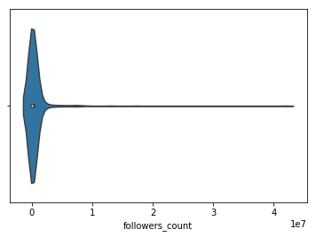

```python
seaborn.violinplot(player_data_df['followers_count'])
```

Yikes! That's a very right skewed data set, but a big part of that is LeBron James, who has over 40 million followers. Let's see what the distribution looks like without him in it.

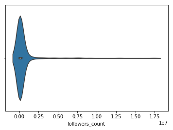

```python
seaborn.violinplot(player_data_df[player_data_df['name'] != 'LeBron James']['followers_count'])
```

That plot was a little bit better, but it's still way right-skewed which prevents us from getting a lot of incormatin about the bulk of the distribution. Let's just look at the players we consider to be "non-stars" - those with under 500 thousand followers. While it is still right skewed, we can see that there is a decent amount of variation in follower count near the low end of the follower count, so we should have a shot at modeling that.

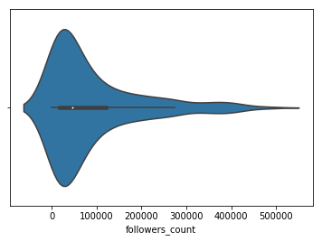

```python
non_stars_max = 500000
non_stars_df = player_data_df[player_data_df['followers_count'] < non_stars_max]
seaborn.violinplot(non_stars_df['followers_count'])
```

```python
np.sum([player_data_df['followers_count'] < non_stars_max])/len(player_data_df)
```

```
0.8699551569506726
```

In general, we would intuitively expect to find that better players tend to have more followers, so let's find out if that visually seems right based on the data we have. We don't have an easy metric for 'good-ness' in basketball like wins above replacement provides in baseball, but our best overall metric would probably be points per game. So we will plot followers count vs points per game and see if there appears to be a correlation.

```
Text(0.5,1,'Followers vs PPG')
```

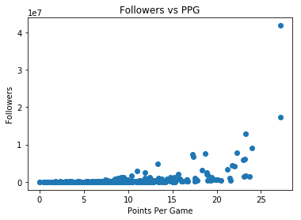

```python
plt.scatter(player_data_df['pts_per_g'], player_data_df['followers_count'])
plt.xlabel('Points Per Game')
plt.ylabel('Followers')
plt.title('Followers vs PPG')
```

There generally appears to be a positive trend, but it's pretty hard to tell because we have such a skewed distribution (thanks LeBron). As we saw earlier, we have a much easier to see distribution if we only consider our non-stars, so lets create the same plot as above but only for non-stars.

In this plot, we find a much easier to see trend. While there is a lot of noise and variance, we do see a definite increasing and approximately linear relationship between points per game and follower count. This shows a lot of promise for creating a regression model later.

```
Text(0.5,1,'Followers vs PPG for Non-Stars')
```

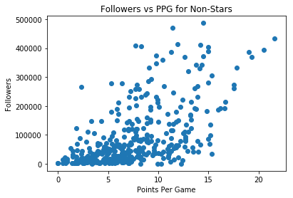

```python
plt.scatter(non_stars_df['pts_per_g'], non_stars_df['followers_count'])
plt.xlabel('Points Per Game')
plt.ylabel('Followers')
plt.title('Followers vs PPG for Non-Stars')
```

Since they are a little strange compared to other stats in our data set, we should also see if it looks like the 'bling' statistics have an effect on follower count. This bling, however, generally belongs to players who are among the very best in the league, and thus have a lot of followers, we will not be able to look at just the non-stars data set. So to make the trends easier to see despite the strong right skew, we will plot the natural log of our follower count.

```
Text(0.5,1,'Followers vs All-Star Appearances')
```

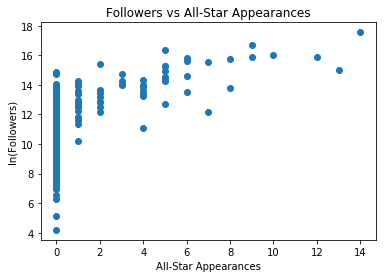

```python
plt.scatter(player_data_df['all_star'], np.log(player_data_df['followers_count']))
plt.xlabel('All-Star Appearances')
plt.ylabel('ln(Followers)')
plt.title('Followers vs All-Star Appearances')
```

```
Text(0.5,1,'Followers vs MVP Awards')
```

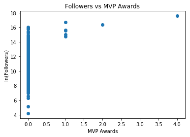

```python
plt.scatter(player_data_df['mvp'], np.log(player_data_df['followers_count']))
plt.xlabel('MVP Awards')
plt.ylabel('ln(Followers)')
plt.title('Followers vs MVP Awards')
```

```
Text(0.5,1,'Followers vs Championships')
```

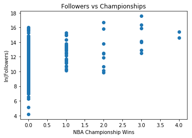

```python
plt.scatter(player_data_df['champ'], np.log(player_data_df['followers_count']))
plt.xlabel('NBA Championship Wins')
plt.ylabel('ln(Followers)')
plt.title('Followers vs Championships')
```

Though it is less obvious whether the trends here are somewhat linear since the followers are on a log scale and there are pretty few players with bling, it is clear that players with bling tend to have higher numbers of Twitter followers.

However, not all of our features will have such a clear correlation with followers. Take salary for example.

We will plot followers vs salary for non-stars and observe the results. Is there correlation in this graph? Maybe a little bit, but it's not great. Almost all the players with a very low salary have a very small number of followers, but this is certainly not as strong as what we've seen above.

```
Text(0.5,1,'Followers vs Salary for Non-Stars')
```

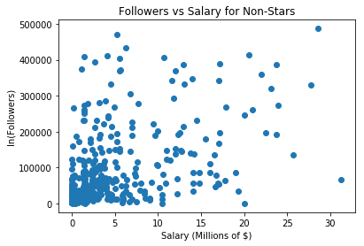

```python
plt.scatter(non_stars_df['salary']/1000000, non_stars_df['followers_count'])
plt.xlabel('Salary (Millions of $)')
plt.ylabel('ln(Followers)')
plt.title('Followers vs Salary for Non-Stars')
```

Even worse, take free throw percentage as an example. When we plot followers vs free throw %, we see that not only is there not much variance in free throw %, it it totally uncorrelated with follower count. We could reasonably expect this to be the case for most of the percentage statistics, because it is so easy for players to achieve very widely varying percentages by having very few attempts in those categories. For this reason, we will leave these features out of our regression model.

```
Text(0.5,1,'Followers vs Free Throw %')
```

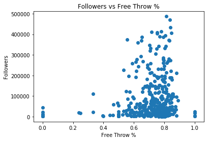

```python
plt.scatter(non_stars_df['ft_pct'], non_stars_df['followers_count'])
plt.xlabel('Free Throw %')
plt.ylabel('Followers')
plt.title('Followers vs Free Throw %')
```

## Initial Model

Now that we have conducted our necessary EDA, we are ready to start creating a model. To start out, we will create a multiple linear regression model on the features we have deemed potentially important. Thos os way too many features and will make our model hard to understand and interpret, but it provides us with a ceiling for our model's performance. For now, we will train and test on all of our data, but we will NOT do this later when we are testing our finalized model.

```python
str_cols = ['name', 'ref', 'handle', 'lg_id']
numeric_cols = [x for x in player_data_df if not x in str_cols]
feature_cols = ['all_star', 'champ', 'mvp', 'efg_pct', 'fg3_pct', 'fg3_per_g', 'ast_per_g', 'rb_per_g','pts_per_g', 'blk_per_g', 'g', 'gs', 'mp_per_g', 'salary']
linear_reg = LinearRegression().fit(player_data_df[feature_cols], player_data_df['followers_count'])
```

We will now score our regression model. The score which is returned to us is our R<sup>2</sup> coefficient, a statistical measure of how close the true data is to our fitted regression model. More specifically, it is the percentage of the response variable variation that is explained by our regression model. You can read more about the meaning of this score [here](http://blog.minitab.com/blog/adventures-in-statistics-2/regression-analysis-how-do-i-interpret-r-squared-and-assess-the-goodness-of-fit).

```python
linear_reg.score(player_data_df[feature_cols], player_data_df['followers_count'])
```

```
0.85092325559170368
```

To get a visual idea of how well our model worked, we can plot our estimated vs correct follower count.

```
Text(0.5,1,'Expected vs True Followers Count')
```

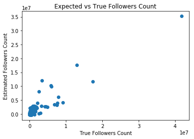

```python
plt.scatter(player_data_df['followers_count'], linear_reg.predict(player_data_df[feature_cols]))
plt.xlabel('True Followers Count')
plt.ylabel('Estimated Followers Count')
plt.title('Expected vs True Followers Count')
```

As they have before, the outliers are making the trends in this data hard to see.

To make it easier to see, we will plot the estimates for only non-stars. In addition, we will plot an x=y line, which is where all of our data points would be if our model was perfect.

We can see that our points generally cluster around the line, which is what we would expect of a good model.

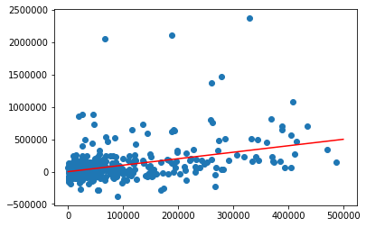

```python
plt.scatter(non_stars_df['followers_count'], linear_reg.predict(non_stars_df[feature_cols]))
plt.plot([0, non_stars_max],[0, non_stars_max], 'r-')
```

# Feature Reduction

We have a number of features that we are trying to relate to Twitter followers. However, which features are going to be the most relavant for us to look at? Some some stats, such as number of season MVP's, seem important. Others, such as 3-point field goal percentage, may not be as strong features. Also, high-dimensionality datasets can be more difficult to analyze. To address this issue, we attemp to reduce the dimensionality by using feature reduction methods. In this section, we use the feature selection techniques used in this [article](https://scikit-learn.org/stable/modules/feature_selection.html) to attempt to reduce our feature matrix size.

First, we [normalize](https://docs.microsoft.com/en-us/azure/machine-learning/studio-module-reference/normalize-data) the data in our current data set using the preprocessing module provided by sklearn. This is a common data preperation technique used in machine learning to change the values in each column of the dataset to use a common scale without losing information. In our case, we do min-max normalization to rescale the features from [0, 1]. The new dataframe containing normalized data is called *norm_player_data_df*.

```python
x = player_data_df[feature_cols]
min_max_scaler = preprocessing.MinMaxScaler()
x_scaled = min_max_scaler.fit_transform(x)
norm_player_data_df = pandas.DataFrame(x_scaled)
norm_player_data_df.columns = feature_cols
norm_player_data_df.head()
```

|  | all_star | champ | mvp | efg_pct | fg3_pct | fg3_per_g | ast_per_g | rb_per_g | pts_per_g | blk_per_g | g | gs | mp_per_g | salary |
| --- | --- | --- | --- | --- | --- | --- | --- | --- | --- | --- | --- | --- | --- | --- |
| 0 | 0.0 | 0.0 | 0.0 | 0.557569 | 0.368 | 0.371429 | 0.051546 | 0.103704 | 0.194853 | 0.04 | 0.112245 | 0.011111 | 0.395225 | 0.165069 |
| 1 | 0.0 | 0.0 | 0.0 | 0.551173 | 0.356 | 0.171429 | 0.061856 | 0.259259 | 0.183824 | 0.16 | 0.221769 | 0.041667 | 0.400531 | 0.049291 |
| 2 | 0.0 | 0.0 | 0.0 | 0.625800 | 0.000 | 0.000000 | 0.092784 | 0.533333 | 0.338235 | 0.40 | 0.279592 | 0.241667 | 0.663130 | 0.647931 |
| 3 | 0.0 | 0.0 | 0.0 | 0.556503 | 0.000 | 0.000000 | 0.154639 | 0.437037 | 0.268382 | 0.28 | 0.064626 | 0.016667 | 0.506631 | 0.071804 |
| 4 | 0.0 | 0.0 | 0.0 | 0.561834 | 0.000 | 0.000000 | 0.051546 | 0.251852 | 0.113971 | 0.28 | 0.229932 | 0.015972 | 0.238727 | 0.210480 |

## First Attempt: L1-based feature selection

We attempt to use the L1-based feature selection described in the feature selection article from above. This method works by creating a linear model to fit our data that has been penalized with the L1 norm; this causes many of the estimated coefficients to be zero, which can be removed from the feature set for further analysis. For our purposes, we use the recommended Lasso linear model as the estimator.

```python
norm_pd = norm_player_data_df
followers = player_data_df['followers_count']
```

```python
lasso_reg = linear_model.Lasso().fit(norm_pd, followers)
model = feature_selection.SelectFromModel(lasso_reg, prefit=True)
print('Removed {:d} features'.format(len(norm_pd.columns[[not x for x in model.get_support()]])))
```

```
Removed 0 features
```

From the above, we can see that the feature selection removed no features from the feature set. This is interesting result! This may mean that all of these features are very useful, or it may mean that the Lasso estimator was not a good fit for this dataset. We will now try another approach, recursive feature elimination

## Second Attempt: Recusive Feature Elimination

This method of feature reduction selects features by recusively removing the least important features in a linear model until the desired number of features is achieved. We choose this number to be 10, which is arbitrarily chosen to keep the feature set small but signifcant.

```python
linear_reg = LinearRegression().fit(norm_pd, followers)
rfe = feature_selection.RFE(estimator=linear_reg, n_features_to_select=10)
rfe.fit(norm_pd, followers)
reduced_features = norm_pd.columns[rfe.support_]
print('Features included:\t', list(reduced_features))
print('Features removed:\t', list(norm_pd.columns[[not x for x in rfe.support_]]))
```

```
Features included:	 ['all_star', 'champ', 'mvp', 'fg3_pct', 'fg3_per_g', 'ast_per_g', 'rb_per_g', 'pts_per_g', 'gs', 'salary']
Features removed:	 ['efg_pct', 'blk_per_g', 'g', 'mp_per_g']
```

We see now that RFE has removed the 4 weakest features in the feature set: effetive field goal percent, blocks per game, games played, and minutes per game. Now, let us see how a linear model trained on the feature matrix with the weakest features removed.

# Building a Model and Evaluating

Lets build a model using our newly obtained feature set and analyze it using itsr-squared. We use the same linear regression model used during EDA.

```python
reduced_features = norm_player_data_df[norm_pd.columns[rfe.support_]]
reduced_reg = LinearRegression().fit(reduced_features, followers)
predict_with_reduced = reduced_reg.predict(norm_player_data_df[norm_pd.columns[rfe.support_]])
print('Coefficients for each label')
print('---------------------------')
for label, coef in zip(reduced_features.columns, reduced_reg.coef_):
    print(label, ':', coef)
print('\nScore for linear regression trained wtih reduced featureset:',
      reduced_reg.score(reduced_features, followers))
```

```
Coefficients for each label
---------------------------
all_star : 5872218.84862
champ : 1784528.70931
mvp : 27869651.2483
fg3_pct : 225279.457095
fg3_per_g : -485461.501946
ast_per_g : 367840.577569
rb_per_g : 290963.349908
pts_per_g : 382799.422076
gs : -1324800.02871
salary : 704326.669473

Score for linear regression trained wtih reduced featureset: 0.850885790098
```

```
Text(0.5,1,'Estimated vs Actual Number of Followers')
```

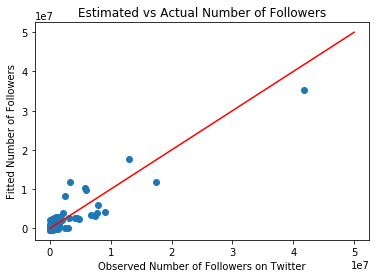

```python
plt.scatter(followers, predict_with_reduced)
plt.plot([0, 50000000],[0, 50000000], 'r-')
plt.xlabel('Observed Number of Followers on Twitter')
plt.ylabel('Fitted Number of Followers')
plt.title('Estimated vs Actual Number of Followers')
```

We would expect the points in the above plot to cluster around the line *y=x*. While it does look like our model meets this criteria, it is difficult to see the error for all the values. To get a better understanding of how good our model is, we will plot the residuals, the error for each prediction, for each player's expected number of Twitter followers vs the actual.

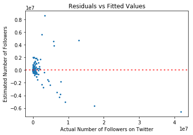

```python
plt.scatter(followers, predict_with_reduced - followers, s=5)
plt.xlabel('Actual Number of Followers on Twitter')
plt.ylabel('Estimated Number of Followers')
plt.title('Residuals vs Fitted Values')
plt.axhline(color='r', dashes=(2,3))
plt.show()
```

As a final test to see our model generalizes for players outside of our collected training data, we split our data into a training and testing set and perform cross validation once.

```python
ss = ShuffleSplit(n_splits=1)

cv_score = cross_val_score(reduced_reg, reduced_features, followers, cv=ss)
cv_score[0]
```

```
0.827476977348784
```

Because our data is not uniformly distributed across Twitter followers due to a few number of superstars, the results can vary wildly depending on this partition. Above, we can see that for this interation of the experiment, we get a score of .827, which indicates a strong correlation between our estimated follower count and the true follower count.

# Conclusion

Our model was able to identify a strong correlation between basketball statistics and number of Twitter followers. But, because of how complicated it is to model Twitter followers and how a basketball player's Twitter following may be influenced by off-court behaviors that are not captured in our data, we cannot say that this model can predict Twitter followers with great accuracy. Also, we were able to collect the top 10 features that predict Twitter follower count, which can be used outside the context of basketball to predict which current players are in positions of influence or would be good candidates to pursue endorsement deals.